# R Recap

Mark Dunning

Last modified: 19 Sep 2016

# A short introduction to R

## Outline

In this session, we review some of the fundamentals of the R language. It should be a useful refresher prior to the intermediate-level [Data Analysis and Visualisation using R](http://bioinformatics-core-shared-training.github.io/r-intermediate/) course.

Topics covered include:-

- Creating variables
- Using Functions
- Vectors
- Data frame
- Subsetting data, the base R way
- Plotting
- Statistical testing
- How to get help

For a more detailed introduction, we suggest the following *free* resources

- [Solving Biological Problems with R](http://cambiotraining.github.io/r-intro/)
- [Introduction to Data Science with R](http://shop.oreilly.com/product/0636920034834.do)
- [Coursera course in R](http://blog.revolutionanalytics.com/2012/12/coursera-videos.html)
- [Beginners Introduction to R Statistical Software](http://bitesizebio.com/webinar/20600/beginners-introduction-to-r-statistical-software/)
- [R programming wiki](https://en.wikibooks.org/wiki/R_Programming)
- [Quick R](http://www.statmethods.net/)

## Advantages of R

The R programming language is now recognised beyond the academic community as an effect solution for data analysis and visualisation. [Notable users of R](http://www.revolutionanalytics.com/companies-using-r) include:-

- [Facebook](http://blog.revolutionanalytics.com/2010/12/analysis-of-facebook-status-updates.html),
- [google](http://blog.revolutionanalytics.com/2009/05/google-using-r-to-analyze-effectiveness-of-tv-ads.html),
- [Microsoft](http://blog.revolutionanalytics.com/2014/05/microsoft-uses-r-for-xbox-matchmaking.html) (who recently [invested](http://blogs.microsoft.com/blog/2015/01/23/microsoft-acquire-revolution-analytics-help-customers-find-big-data-value-advanced-statistical-analysis/) in a commerical provider of R)
- The [New York Times](http://blog.revolutionanalytics.com/2011/03/how-the-new-york-times-uses-r-for-data-visualization.html).
- [Buzzfeed](http://blog.revolutionanalytics.com/2015/12/buzzfeed-uses-r-for-data-journalism.html) use R for some of their serious articles (i.e. not the ones featuring cat pictures), and have made the code [publically available](https://buzzfeednews.github.io/2016-04-federal-surveillance-planes/analysis.html)
- The [New Zealand Tourist Board](https://mbienz.shinyapps.io/tourism_dashboard_prod/) have R running in the background of their website
- [Airbnb](https://medium.com/airbnb-engineering/using-r-packages-and-education-to-scale-data-science-at-airbnb-906faa58e12d)

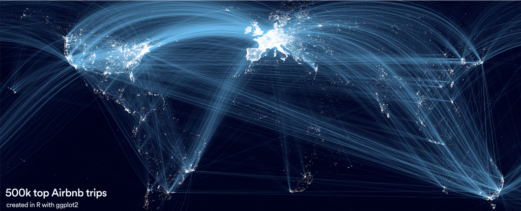

## Key features

- Open-source
- Cross-platform
- Access to existing visualisation / statistical tools
- Flexibility
- Visualisation and interactivity
- Add-ons for many fields of research
- Facilitating *Reproducible Research*

duke-scandal

Two Biostatiscians (later termed ‘*Forensic Bioinformaticians*’) from M.D. Anderson used R extensively during their re-analysis and investigation of a Clinical Prognostication paper from Duke. The subsequent [scandal](https://www.youtube.com/watch?v=W5sZTNPMQRM) put Reproducible Research at the forefront of everyone’s mind.

Keith Baggerly’s talk on the subject is highy-recommended.

[video not shown]

## Support for R

- Online forums such as [Stack Overflow](http://stackoverflow.com/questions/tagged/r) regularly feature R
- [Blogs](http://www.r-bloggers.com/)
- Local [user groups](http://blog.revolutionanalytics.com/local-r-groups.html)
- Documentation via `?` or `help.start()`
- Packages analyse all kinds of Genomic data (>800)
- Compulsory documentation (*vignettes*) for each package
- 6-month release cycle
- [Course Materials](http://bioconductor.org/help/course-materials/)
- [Example data](http://bioconductor.org/packages/release/BiocViews.html#___ExperimentData) and [workflows](http://bioconductor.org/help/workflows/)
- Common, re-usable framework and functionality
- [Available Support](https://support.bioconductor.org/)
  - Often you will be able to interact with the package maintainers / developers and other power-users of the project software
- Annual conferences in U.S and Europe
  - The last European conference was in [Cambridge](https://sites.google.com/site/eurobioc2015/)

## RStudio

- Rstudio is a free environment for R
- Convenient menus to access scripts, display plots
- Still need to use *command-line* to get things done
- Developed by some of the leading R programmers
- Used by beginners, and experienced users alike

To get started, you will need to install the [latest version of R](https://cran.r-project.org/) and [RStudio Desktop](https://www.rstudio.com/products/rstudio/download3/); both of which are *free*.

The bottom-left with the blinking cursor is the R console `>` and ready for you to start entering R commands

# Getting started

[figure not shown]

At a basic level, we can use R as a calculator to compute simple sums with the `+`, `-`, `*` (for multiplication) and `/` (for division) symbols.

```r
2 + 2
```

```
## [1] 4
```

```r
2 - 2
```

```
## [1] 0
```

```r
4 * 3
```

```
## [1] 12
```

```r
10 / 2
```

```
## [1] 5
```

The answer is displayed at the console with a `[1]` in front of it. The `1` inside the square brackets is a place-holder to signify how many values were in the answer (in this case only one). We will talk about dealing with lists of numbers shortly…

In the case of expressions involving multiple operations, R respects the [BODMAS](https://en.wikipedia.org/wiki/Order_of_operations#Mnemonics) system to decide the order in which operations should be performed.

```r
2 + 2 *3
```

```
## [1] 8
```

```r
2 + (2 * 3)
```

```
## [1] 8
```

```r
(2 + 2) * 3
```

```
## [1] 12
```

R is capable of more complicated arithmetic such as trigonometry and logarithms; like you would find on a fancy scientific calculator. Of course, R also has a plethora of statistical operations as we will see.

[figure not shown]

```r
pi
```

```
## [1] 3.141593
```

```r
sin (pi/2)
```

```
## [1] 1
```

```r
cos(pi)
```

```
## [1] -1
```

```r
tan(2)
```

```
## [1] -2.18504
```

```r
log(1)
```

```
## [1] 0
```

We can only go so far with performing simple calculations like this. Eventually we will need to store our results for later use. For this, we need to make use of *variables*.

## Variables

A variable is a letter or word which takes (or contains) a value. We use the assignment ‘operator’, `<-` to create a variable and store some value in it.

```r
x <- 10
x
```

```
## [1] 10
```

```r
myNumber <- 25
myNumber
```

```
## [1] 25
```

We also can perform arithmetic on variables using functions:

```r
sqrt(myNumber)
```

```
## [1] 5
```

We can add variables together:

```r
x + myNumber
```

```
## [1] 35
```

We can change the value of an existing variable:

```r
x <- 21
x
```

```
## [1] 21
```

- We can set one variable to equal the value of another variable:

```r
x <- myNumber
x
```

```
## [1] 25
```

- We can modify the contents of a variable:

```r
myNumber <- myNumber + sqrt(16)
myNumber
```

```
## [1] 29
```

When we are feeling lazy we might give our variables short names (`x`, `y`, `i`…etc), but a better practice would be to give them meaningful names. There are some restrictions on creating variable names. They cannot start with a number or contain characters such as `.`, `_`, ‘-’. Naming variables the same as in-built functions in R, such as `c`, `T`, `mean` should also be avoided.

## Functions

**Functions** in R perform operations on **arguments** (the inputs(s) to the function). We have already used:

```r
sin(x)
```

this returns the sine of x. In this case the function has one argument: **x**. Arguments are always contained in parentheses – curved brackets, **()** – separated by commas.

Arguments can be named or unnamed, but if they are unnamed they must be ordered (we will see later how to find the right order). The names of the arguments are determined by the author of the function and can be found in the help page for the function. When testing code, it is easier and safer to name the arguments. `seq` is a function for generating a numeric sequence *from* and *to* particular numbers. Type `?seq` to get the help page for this function.

```r
seq(from = 2, to = 20, by = 4)
```

```
## [1]  2  6 10 14 18
```

```r
seq(2, 20, 4)
```

```
## [1]  2  6 10 14 18
```

Arguments can have *default* values, meaning we do not need to specify values for these in order to run the function.

`rnorm` is a function that will generate a series of values from a *normal distribution*. In order to use the function, we need to tell R how many values we want

```r
rnorm(n=10)
```

```
##  [1] -0.7165694 -0.3380531  0.9222729  1.1024231 -1.3926559 -0.4611434
##  [7] -0.1545351 -0.5193794 -0.9660563  0.3039010
```

The normal distribution is defined by a *mean* (average) and *standard deviation* (spread). However, in the above example we didn’t tell R what mean and standard deviation we wanted. So how does R know what to do? All arguments to a function and their default values are listed in the help page

(*N.B sometimes help pages can describe more than one function*)

```r
?rnorm
```

In this case, we see that the defaults for mean and standard deviation are 0 and 1. We can change the function to generate values from a distribution with a different mean and standard deviation using the `mean` and `sd` *arguments*. It is important that we get the spelling of these arguments exactly right, otherwise R will an error message, or (worse?) do something unexpected.

```r
rnorm(n=10, mean=2,sd=3)
```

```
##  [1] 3.0515410 1.5794268 2.0520589 0.7369639 2.6579879 2.4157351 0.2491450
##  [8] 0.1583003 1.0917802 0.7151099
```

```r
rnorm(10, 2, 3)
```

```
##  [1] -1.6735816  1.7029457  2.2302577  1.8810765  2.8122275  1.0292247
##  [7] -0.7342262  3.1038683  3.4322720  0.6593687
```

In the examples above, `seq` and `rnorm` were both outputting a series of numbers, which is called a *vector* in R and is the most-fundamental data-type.

## Vectors

- The basic data structure in R is a **vector** – an ordered collection of values.
- R treats even single values as 1-element vectors.
- The function `c` *combines* its arguments into a vector:
- Remember that as `c` is a function, we specify it’s arguments in curved brackets`(...)`

```r
x <- c(3,4,5,6)
x
```

```
## [1] 3 4 5 6
```

The square brackets `[]` indicate the position within the vector (the *index*). We can extract individual elements by using the `[]` notation:

```r
x[1]
```

```
## [1] 3
```

```r
x[4]
```

```
## [1] 6
```

We can even put a vector inside the square brackets: (*vector indexing*)

```r
y <- c(2,3)
x[y]
```

```
## [1] 4 5
```

When applying all standard arithmetic operations to vectors, application is element-wise. Thus, we say that R supports *vectorised* operations.

```r
x <- 1:10
y <- x*2
y
```

```
##  [1]  2  4  6  8 10 12 14 16 18 20
```

```r
z <- x^2

x + y
```

```
##  [1]  3  6  9 12 15 18 21 24 27 30
```

Vectorised operations are extremely powerful. Operations that would require a *for* loop (or similar) in other languages such as **C**, **Python**, can be performed in a single line of R code.

A vector can also contain text; called a character vector. Such a vector can also be constructed using the `c` function.

```r
x <- c("A","B","C","D")
```

Another useful type of data that we will see is the *logical* or *boolean* which can take either the values of `TRUE` or `FALSE`

```r
x <- c(TRUE,TRUE,FALSE)
```

Logical values are useful when we want to create subsets of our data. We can use *comparison* operators; `==`, `>`, `<`, `!=` to check if values are equal, greater than, less than, or not equal.

```r
x <- c("A","A", "B","B","C")
x == "A"
```

```
## [1]  TRUE  TRUE FALSE FALSE FALSE
```

```r
x <- rnorm(10)
x > 0
```

```
##  [1] FALSE FALSE FALSE FALSE  TRUE FALSE FALSE FALSE FALSE  TRUE
```

However, all items in the vector **must** be the same type. If you attempt anything else, R will convert all values to the same (most basic) type.

```r
x <- c(1, 2, "three")
x
```

```
## [1] "1"     "2"     "three"
```

## Packages in R

So far we have used functions that are available with the *base* distribution of R; the functions you get with a clean install of R. The open-source nature of R encourages others to write their own functions for their particular data-type or analyses.

Packages are distributed through *repositories*. The most-common ones are CRAN and Bioconductor. CRAN alone has many thousands of packages.

The **Packages** tab in the bottom-right panel of RStudio lists all packages that you currently have installed. Clicking on a package name will show a list of functions that available once that package has been loaded. The `library` function is used to load a package and make it’s functions / data available in your current R session. *You need to do this every time you load a new RStudio session*.

```r
library(beadarray)
```

There are functions for installing packages within R. If your package is part of the main **CRAN** repository, you can use `install.packages`

We will be using the `gapminder` R package in this practical. To install it, we would do.

```r
install.packages("gapminder")
```

*Bioconductor* packages have their own install script, which you can download from the Bioconductor website

```r
source("http://www.bioconductor.org/biocLite.R")
biocLite("affy")
```

A package may have several *dependancies*; other R packages from which it uses functions or data types (re-using code from other packages is strongly-encouraged). If this is the case, the other R packages will be located and installed too.

**So long as you stick with the same version of R, you won’t need to repeat this install process.**

# R walkthrough

We are going to explore some of the basic features of R using data from the [gapminder](https://www.gapminder.org/data/) project, which have been bundled into an [R package](https://github.com/jennybc/gapminder). These data give various indicator variables for different countries around the world (life expectancy, population and Gross Domestic Product). We have saved these data as a `.csv` file to demonstrate how to import data into R.

You can download these data [here](https://raw.githubusercontent.com/bioinformatics-core-shared-training/r-intermediate/master/gapminder.csv). Right-click the link and save to somewhere on your computer that you wish to work from.

## The working directory

Like other software (Word, Excel, Photoshop….), R has a default location where it will save files to and import data from. Equivalent to selecting *File - Save* or *File - Open* from those other tools, we don’t have to tell R where we want data and plots etc to be saved. This is known as the *working directory* in R. You can query what R currently considers its working directory by doing:-

```r
getwd()
```

*N.B. Here, a set of open and closed brackets `()` is used to call the `getwd` function with no arguments.*

We can also list the files in this directory with:-

```
list.files()
```

Any `.csv` file in the working directory can be imported into R by supplying the name of the file to the `read.csv` function and creating a new variable to store the result. A useful sanity check is the `file.exists` function which will print `TRUE` is the file can be found in the working directory.

```r
file.exists("gapminder.csv")
```

```
## [1] TRUE
```

```r
gapminder <- read.csv("gapminder.csv")
```

The data frame object in R allows us to work with “tabular” data, like we might be used to dealing with in Excel, where our data can be thought of having rows and columns. The values in each column have to all be of the same type (i.e. all numbers or all text).

In Rstudio , you can view the contents of the data frame we have just created. This is useful for interactive exploration of the data, but not so useful for automation and scripting and analyses.

```r
View(gapminder)
```

### Exercise

- What are the dimensions of the data frame?
- What columns are available?
- HINT: see the `dim`, `ncol`, `nrow` and `colnames` functions

```
## [1] 1704    6
```

```
## [1] "country"   "continent" "year"      "lifeExp"   "pop"       "gdpPercap"
```

We can access the columns of a data frame by knowing the column name. *TIP* Use auto-complete with the *TAB* key to get the name of the column correct

```r
gapminder$country
```

A vector (1-dimensional) is returned, the length of which is the same as the number of rows in the data frame. The vector could be stored as a variable and itself be subset or used in further calculations

```
## [1] 1704
```

The `summary` function is a useful way of summarising the data containing in each column. It will give information about the *type* of data (remember, data frames can have a mixture of numeric and character columns) and also an appropriate summary. For numeric columns, it will report some stats about the distribution of the data. For categorical data, it will report the different *levels*.

```r
summary(gapminder)
```

```
##         country        continent        year         lifeExp
##  Afghanistan:  12   Africa  :624   Min.   :1952   Min.   :23.60
##  Albania    :  12   Americas:300   1st Qu.:1966   1st Qu.:48.20
##  Algeria    :  12   Asia    :396   Median :1980   Median :60.71
##  Angola     :  12   Europe  :360   Mean   :1980   Mean   :59.47
##  Argentina  :  12   Oceania : 24   3rd Qu.:1993   3rd Qu.:70.85
##  Australia  :  12                  Max.   :2007   Max.   :82.60
##  (Other)    :1632
##       pop              gdpPercap
##  Min.   :6.001e+04   Min.   :   241.2
##  1st Qu.:2.794e+06   1st Qu.:  1202.1
##  Median :7.024e+06   Median :  3531.8
##  Mean   :2.960e+07   Mean   :  7215.3
##  3rd Qu.:1.959e+07   3rd Qu.:  9325.5
##  Max.   :1.319e+09   Max.   :113523.1
##
```

### Exercise

- Save the life expectancy and population as variables
  - what is the maximum life expectancy?
  - what is the smallest population?
  - round the life expectancy and populations to the nearest whole numbers
  - HINT:- `min`, `max`, `round`…..

## Subsetting

A data frame can be subset using square brackes`[]` placed after the name of the data frame. As a data frame is a two-dimensional object, you need a *row* and *column* index, or vector indices.

*Disclaimer 1*:- later in the course, we will see a slightly-nicer way of subsetting and filtering which will be useful in some circumstances

### Exercise

- Make sure you can understand the behaviour of the following commands

```r
gapminder[1,2]
gapminder[2,1]
gapminder[c(1,2,3),1]
gapminder[c(1,2,3),c(1,2,3)]
```

*Note that the data frame is not altered* we are just seeing what a subset of the data looks like and not changing the underlying data. If we wanted to do this, we would need to create a new variale.

```r
gapminder
```

Should we wish to see all rows, or all columns, we can neglect either the row or column index

### Exercise

- Make sure you can understand the behaviour of the following commands

```r
gapminder[1,]
gapminder[,1]
gapminder[,c(1,2)]
```

- **HINT** `head` is commonly-used to give a snapshot of a data frame.

```r
head(gapminder)
```

```
##       country continent year lifeExp      pop gdpPercap
## 1 Afghanistan      Asia 1952  28.801  8425333  779.4453
## 2 Afghanistan      Asia 1957  30.332  9240934  820.8530
## 3 Afghanistan      Asia 1962  31.997 10267083  853.1007
## 4 Afghanistan      Asia 1967  34.020 11537966  836.1971
## 5 Afghanistan      Asia 1972  36.088 13079460  739.9811
## 6 Afghanistan      Asia 1977  38.438 14880372  786.1134
```

Rather than selecting rows based on their *numeric* index (as in the previous example) we can use what we call a *logical test*. This is a test that gives either a `TRUE` or `FALSE` result. When applied to subsetting, only rows with a `TRUE` result get returned.

For example we could compare the `lifeExp` variable to 40. The result is a *vector* of `TRUE` or `FALSE`; one for each row in the data frame

```r
gapminder$lifeExp < 40
```

This R code can be put inside the square brackets to select rows of interest (those observations where the life expectancy variable is less than 40.

```r
gapminder[gapminder$lifeExp < 40, ]
```

```
##       country continent year lifeExp      pop gdpPercap
## 1 Afghanistan      Asia 1952  28.801  8425333  779.4453
## 2 Afghanistan      Asia 1957  30.332  9240934  820.8530
## 3 Afghanistan      Asia 1962  31.997 10267083  853.1007
## 4 Afghanistan      Asia 1967  34.020 11537966  836.1971
## 5 Afghanistan      Asia 1972  36.088 13079460  739.9811
## 6 Afghanistan      Asia 1977  38.438 14880372  786.1134
```

The `,` is important as this tells R to display all columns. If we wanted a subset of the columns we would put their indices after the `,`

```r
gapminder[gapminder$lifeExp < 40, 1:4]
```

```
##       country continent year lifeExp
## 1 Afghanistan      Asia 1952  28.801
## 2 Afghanistan      Asia 1957  30.332
## 3 Afghanistan      Asia 1962  31.997
## 4 Afghanistan      Asia 1967  34.020
## 5 Afghanistan      Asia 1972  36.088
## 6 Afghanistan      Asia 1977  38.438
```

Testing for equality can be done using `==`. This will only give `TRUE` for entries that are *exactly* the same as the test string.

```r
gapminder[gapminder$country == "Zambia",]
```

```
##      country continent year lifeExp      pop gdpPercap
## 1681  Zambia    Africa 1952  42.038  2672000  1147.389
## 1682  Zambia    Africa 1957  44.077  3016000  1311.957
## 1683  Zambia    Africa 1962  46.023  3421000  1452.726
## 1684  Zambia    Africa 1967  47.768  3900000  1777.077
## 1685  Zambia    Africa 1972  50.107  4506497  1773.498
## 1686  Zambia    Africa 1977  51.386  5216550  1588.688
## 1687  Zambia    Africa 1982  51.821  6100407  1408.679
## 1688  Zambia    Africa 1987  50.821  7272406  1213.315
## 1689  Zambia    Africa 1992  46.100  8381163  1210.885
## 1690  Zambia    Africa 1997  40.238  9417789  1071.354
## 1691  Zambia    Africa 2002  39.193 10595811  1071.614
## 1692  Zambia    Africa 2007  42.384 11746035  1271.212
```

N.B. For partial matches, the `grep` function and / or *regular expressions* (if you know them) can be used.

```r
gapminder[grep("and", gapminder$country),]
```

```
##                     country continent year lifeExp      pop  gdpPercap
## 145  Bosnia and Herzegovina    Europe 1952  53.820  2791000   973.5332
## 146  Bosnia and Herzegovina    Europe 1957  58.450  3076000  1353.9892
## 147  Bosnia and Herzegovina    Europe 1962  61.930  3349000  1709.6837
## 148  Bosnia and Herzegovina    Europe 1967  64.790  3585000  2172.3524
## 149  Bosnia and Herzegovina    Europe 1972  67.450  3819000  2860.1698
## 150  Bosnia and Herzegovina    Europe 1977  69.860  4086000  3528.4813
## 151  Bosnia and Herzegovina    Europe 1982  70.690  4172693  4126.6132
## 152  Bosnia and Herzegovina    Europe 1987  71.140  4338977  4314.1148
## 153  Bosnia and Herzegovina    Europe 1992  72.178  4256013  2546.7814
## 154  Bosnia and Herzegovina    Europe 1997  73.244  3607000  4766.3559
## 155  Bosnia and Herzegovina    Europe 2002  74.090  4165416  6018.9752
## 156  Bosnia and Herzegovina    Europe 2007  74.852  4552198  7446.2988
## 517                 Finland    Europe 1952  66.550  4090500  6424.5191
## 518                 Finland    Europe 1957  67.490  4324000  7545.4154
```

[output cut: 166 more lines]

There are a couple of ways of testing for more than one text value. The first uses an *or* `|` statement. i.e. testing if the value of `country` is `Zambia` *or* the value is `Zimbabwe`.

The `%in%` function is a convenient function for testing which items in a vector correspond to a defined set of values.

```r
gapminder[gapminder$country == "Zambia" | gapminder$country == "Zimbabwe",]
```

```
##       country continent year lifeExp      pop gdpPercap
## 1681   Zambia    Africa 1952  42.038  2672000 1147.3888
## 1682   Zambia    Africa 1957  44.077  3016000 1311.9568
## 1683   Zambia    Africa 1962  46.023  3421000 1452.7258
## 1684   Zambia    Africa 1967  47.768  3900000 1777.0773
## 1685   Zambia    Africa 1972  50.107  4506497 1773.4983
## 1686   Zambia    Africa 1977  51.386  5216550 1588.6883
## 1687   Zambia    Africa 1982  51.821  6100407 1408.6786
## 1688   Zambia    Africa 1987  50.821  7272406 1213.3151
## 1689   Zambia    Africa 1992  46.100  8381163 1210.8846
## 1690   Zambia    Africa 1997  40.238  9417789 1071.3538
## 1691   Zambia    Africa 2002  39.193 10595811 1071.6139
## 1692   Zambia    Africa 2007  42.384 11746035 1271.2116
## 1693 Zimbabwe    Africa 1952  48.451  3080907  406.8841
## 1694 Zimbabwe    Africa 1957  50.469  3646340  518.7643
## 1695 Zimbabwe    Africa 1962  52.358  4277736  527.2722
## 1696 Zimbabwe    Africa 1967  53.995  4995432  569.7951
## 1697 Zimbabwe    Africa 1972  55.635  5861135  799.3622
## 1698 Zimbabwe    Africa 1977  57.674  6642107  685.5877
## 1699 Zimbabwe    Africa 1982  60.363  7636524  788.8550
## 1700 Zimbabwe    Africa 1987  62.351  9216418  706.1573
## 1701 Zimbabwe    Africa 1992  60.377 10704340  693.4208
## 1702 Zimbabwe    Africa 1997  46.809 11404948  792.4500
## 1703 Zimbabwe    Africa 2002  39.989 11926563  672.0386
## 1704 Zimbabwe    Africa 2007  43.487 12311143  469.7093
```

```r
gapminder[gapminder$country %in% c("Zambia","Zimbabwe"),]
```

```
##       country continent year lifeExp      pop gdpPercap
## 1681   Zambia    Africa 1952  42.038  2672000 1147.3888
## 1682   Zambia    Africa 1957  44.077  3016000 1311.9568
## 1683   Zambia    Africa 1962  46.023  3421000 1452.7258
## 1684   Zambia    Africa 1967  47.768  3900000 1777.0773
## 1685   Zambia    Africa 1972  50.107  4506497 1773.4983
## 1686   Zambia    Africa 1977  51.386  5216550 1588.6883
## 1687   Zambia    Africa 1982  51.821  6100407 1408.6786
## 1688   Zambia    Africa 1987  50.821  7272406 1213.3151
## 1689   Zambia    Africa 1992  46.100  8381163 1210.8846
## 1690   Zambia    Africa 1997  40.238  9417789 1071.3538
## 1691   Zambia    Africa 2002  39.193 10595811 1071.6139
## 1692   Zambia    Africa 2007  42.384 11746035 1271.2116
## 1693 Zimbabwe    Africa 1952  48.451  3080907  406.8841
## 1694 Zimbabwe    Africa 1957  50.469  3646340  518.7643
## 1695 Zimbabwe    Africa 1962  52.358  4277736  527.2722
## 1696 Zimbabwe    Africa 1967  53.995  4995432  569.7951
## 1697 Zimbabwe    Africa 1972  55.635  5861135  799.3622
## 1698 Zimbabwe    Africa 1977  57.674  6642107  685.5877
## 1699 Zimbabwe    Africa 1982  60.363  7636524  788.8550
## 1700 Zimbabwe    Africa 1987  62.351  9216418  706.1573
## 1701 Zimbabwe    Africa 1992  60.377 10704340  693.4208
## 1702 Zimbabwe    Africa 1997  46.809 11404948  792.4500
## 1703 Zimbabwe    Africa 2002  39.989 11926563  672.0386
## 1704 Zimbabwe    Africa 2007  43.487 12311143  469.7093
```

Similar to *or*, we can require that both tests are `TRUE` by using an *and* `&` operation. e.g. which years in Zambia had a life expectancy less than 40

```r
gapminder[gapminder$country == "Zambia" & gapminder$lifeExp < 40,]
```

```
##      country continent year lifeExp      pop gdpPercap
## 1691  Zambia    Africa 2002  39.193 10595811  1071.614
```

### Exercise

- Can you create a data frame of countries with a population less than a million in the year 2002

```
##                    country continent year lifeExp    pop gdpPercap
## 95                 Bahrain      Asia 2002  74.795 656397 23403.559
## 323                Comoros    Africa 2002  62.974 614382  1075.812
## 431               Djibouti    Africa 2002  53.373 447416  1908.261
## 491      Equatorial Guinea    Africa 2002  49.348 495627  7703.496
## 695                Iceland    Europe 2002  80.500 288030 31163.202
## 1019            Montenegro    Europe 2002  73.981 720230  6557.194
## 1271               Reunion    Africa 2002  75.744 743981  6316.165
## 1307 Sao Tome and Principe    Africa 2002  64.337 170372  1353.092
```

## Ordering and sorting

A vector can be returned in sorted form using the `sort` function.

```r
sort(countries)
sort(countries,decreasing = TRUE)
```

However, if we want to sort an entire data frame a different approach is needed. The trick is to use `order`. Rather than giving a sorted set of *values*, it will give sorted *indices*. These indices can then be used for a subset operation.

```r
leastPop <- gapminder[order(gapminder$pop),]
head(leastPop)
```

```
##                    country continent year lifeExp   pop gdpPercap
## 1297 Sao Tome and Principe    Africa 1952  46.471 60011  879.5836
## 1298 Sao Tome and Principe    Africa 1957  48.945 61325  860.7369
## 421               Djibouti    Africa 1952  34.812 63149 2669.5295
## 1299 Sao Tome and Principe    Africa 1962  51.893 65345 1071.5511
## 1300 Sao Tome and Principe    Africa 1967  54.425 70787 1384.8406
## 422               Djibouti    Africa 1957  37.328 71851 2864.9691
```

A final point on data frames is that we can export them out of R once we have done our data processing.

```r
byWealth <- gapminder[order(gapminder$gdpPercap,decreasing = TRUE),]
head(byWealth)
```

```
##     country continent year lifeExp     pop gdpPercap
## 854  Kuwait      Asia 1957  58.033  212846 113523.13
## 857  Kuwait      Asia 1972  67.712  841934 109347.87
## 853  Kuwait      Asia 1952  55.565  160000 108382.35
## 855  Kuwait      Asia 1962  60.470  358266  95458.11
## 856  Kuwait      Asia 1967  64.624  575003  80894.88
## 858  Kuwait      Asia 1977  69.343 1140357  59265.48
```

```r
write.csv(byWealth, file="dataOrderedByWealth.csv")
```

## Simple plotting

All your favourite types of plot can be created in R

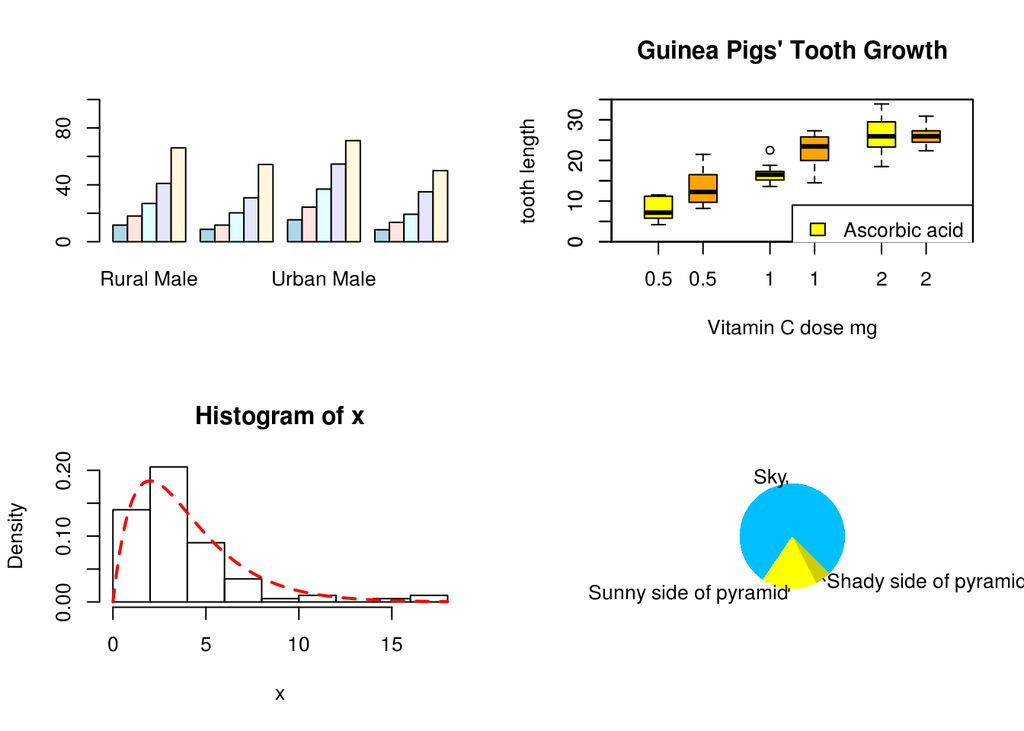

- Simple plots are supported in the *base* distribution of R (what you get automatically when you download R).
  - `boxplot`, `hist`, `barplot`,… all of which are extensions of the basic `plot` function
- Many different customisations are possible
  - colour, overlay points / text, legends, multi-panel figures
- *You need to think about how best to visualise your data*
  - http://www.bioinformatics.babraham.ac.uk/training.html#figuredesign
- R cannot prevent you from creating a plotting disaster:
  - http://www.businessinsider.com/the-27-worst-charts-of-all-time-2013-6?op=1&IR=T
- References..
  - [Introductory R course](http://cambiotraining.github.io/r-intro/)
  - [Quick-R](http://www.statmethods.net/graphs/index.html)

*Disclaimer 2*:- later in the course, we will see a slightly-nicer way of plotting using `ggplot2`.

Plots can be constructed from vectors of numeric data, such as the data we get from a particular column in a data frame

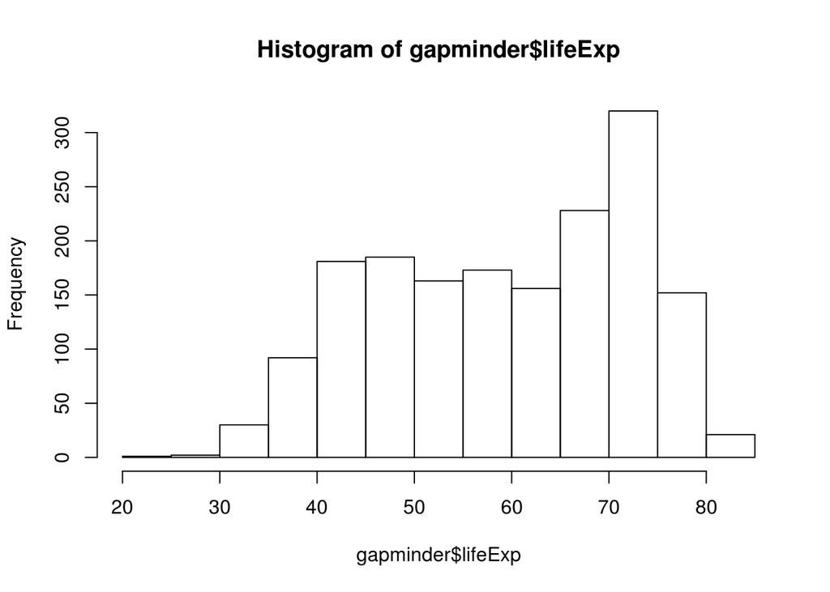

```r
hist(gapminder$lifeExp)
```

Scatter plots of two variables require two arguments; one for the `x` and one for the `y` axis.

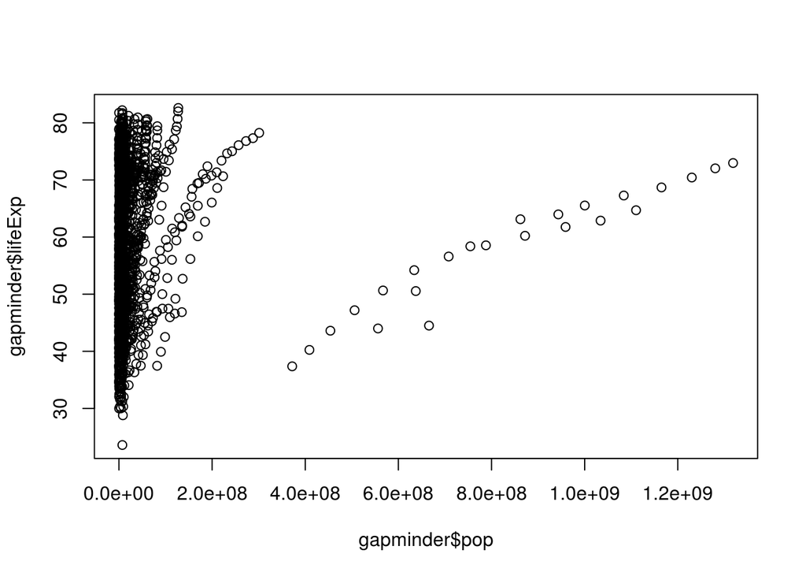

```r
plot(gapminder$pop,gapminder$lifeExp)
```

Barplots are commonly-used for counts of categorical data

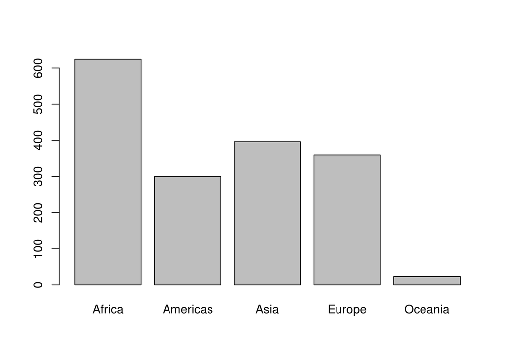

```r
barplot(table(gapminder$continent))
```

Boxplots are good for visualising and comparing distributions. Here the `~` symbol sets up a formula, the effect of which is to put the categorical variable on the `x` axis and continuous variable on the `y` axis.

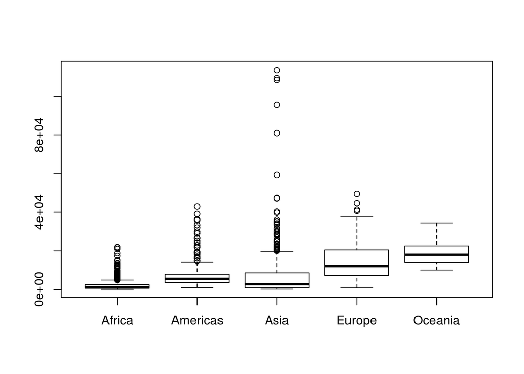

```r
boxplot(gapminder$gdpPercap ~ gapminder$continent)
```

*Lots* of customisations are possible to enhance the appaerance of our plots. Not for the faint-hearted, the help pages `?plot` and `?par` give the full details. In short,

- Axis labels, and titles can be specified as character strings.
- R recognises many preset names as colours. To get a full list use `colours()`, or check this [online reference](http://www.stat.columbia.edu/~tzheng/files/Rcolor.pdf).
- Plotting characters can be specified using a pre-defined number:-

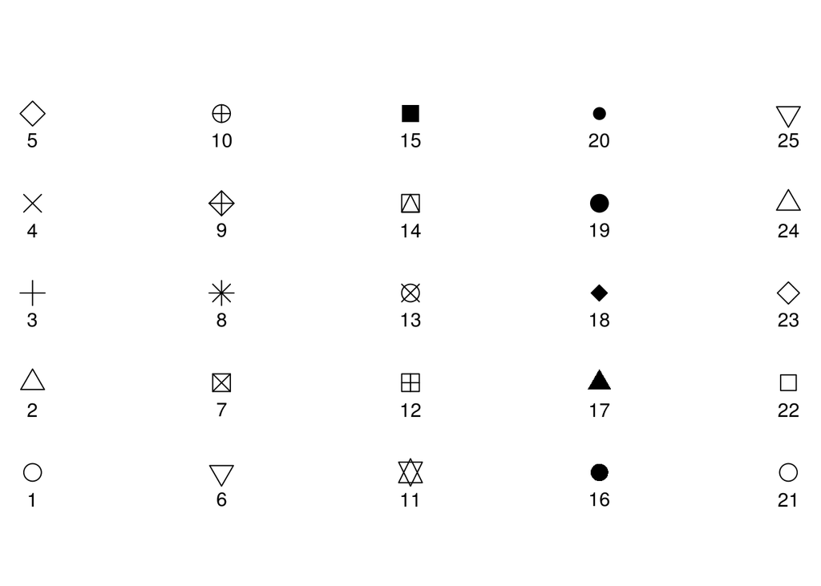

Putting it all together.

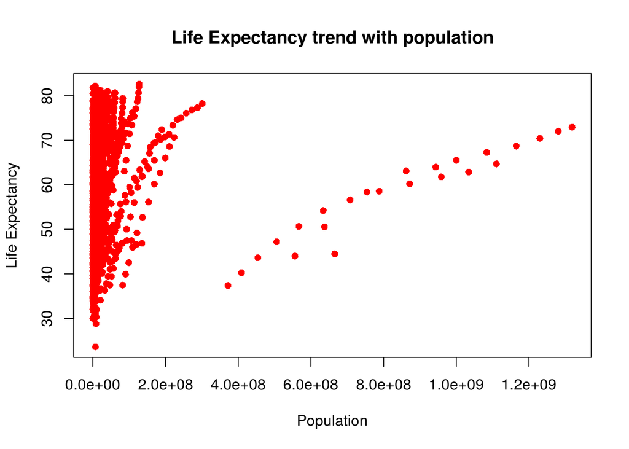

```r
plot(gapminder$pop,gapminder$lifeExp,pch=16,
     col="red",ylab="Life Expectancy",
     xlab="Population",main="Life Expectancy trend with population")
```

The same customisations can be used for various plots:-

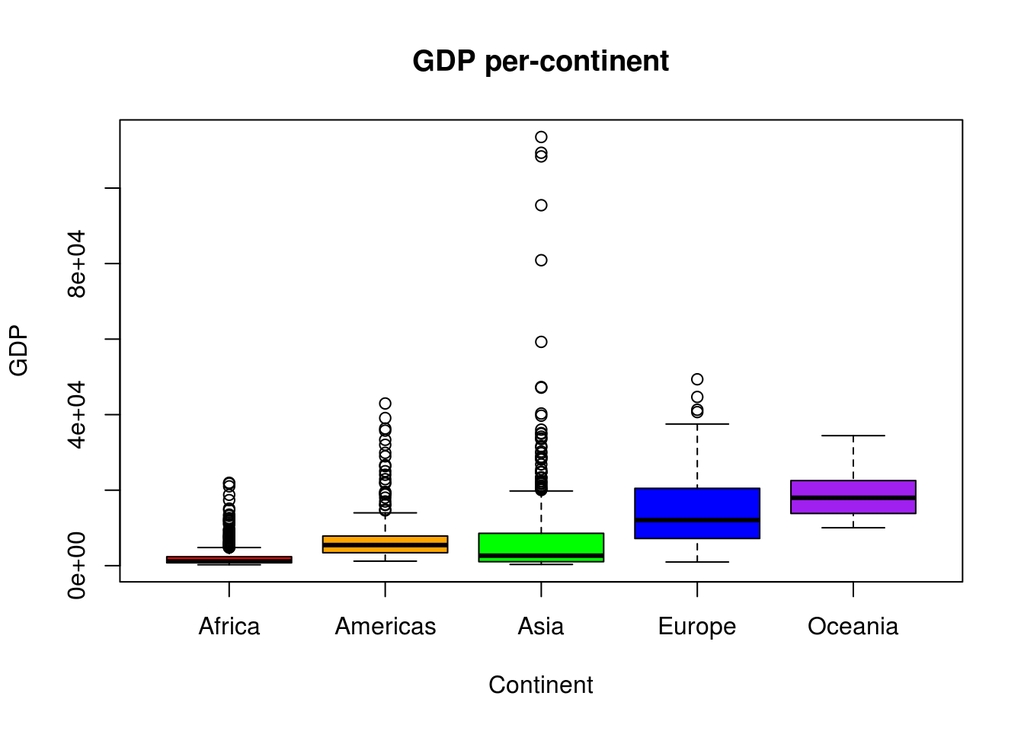

```r
boxplot(gapminder$gdpPercap ~ gapminder$continent,col=c("red","orange","green","blue","purple"),
        main="GDP per-continent",
        xlab="Continent",
        ylab="GDP")
```

Plots can be exported by the *Plots* tab in RStudio, which is useful in an interactive setting. However, one can also save plots to a file calling the `pdf` or `png` functions before executing the code to create the plot.

```r
pdf("myLittlePlot.pdf")
barplot(table(gapminder$continent))
dev.off()
```

Any plots created in-between the `pdf(..)` and `dev.off()` lines will get saved to the named file. The `dev.off()` line is very important; without it you will not be able to view the plot you have created. `pdf` files are useful because you can create documents with multiple pages. Moreover, they can be imported into tools such as Adobe Illustrator to be incorporated with other graphics.

## The canvas model

It is important to realise that base graphics in R uses a *“canvas model”* to create graphics. We can only overlay extra information on-top of an exising plot and cannot “undo” what is already drawn.

Let’s suppose we want to visualise and life expectancy and population of countries in Europe and Africa. First, create two datasets to represent European and African countries in the year 2002

```r
euroData <- gapminder[gapminder$continent == "Europe" & gapminder$year == 2002,]
dim(euroData)
```

```
## [1] 30  6
```

```r
afrData <- gapminder[gapminder$continent == "Africa" & gapminder$year == 2002,]
dim(afrData)
```

```
## [1] 52  6
```

We can start by plotting the life expectancy of the European countries as red dots.

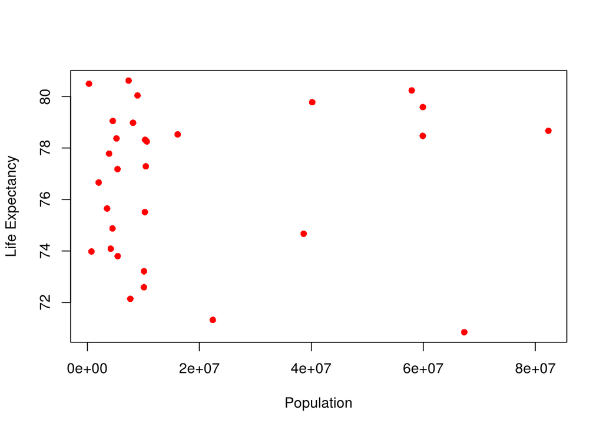

```r
plot(euroData$pop, euroData$lifeExp,col="red",
     pch=16,
     xlab="Population",
     ylab="Life Expectancy")
```

The `points` function can be used put extra points corresponding to African countries on the existing plot.

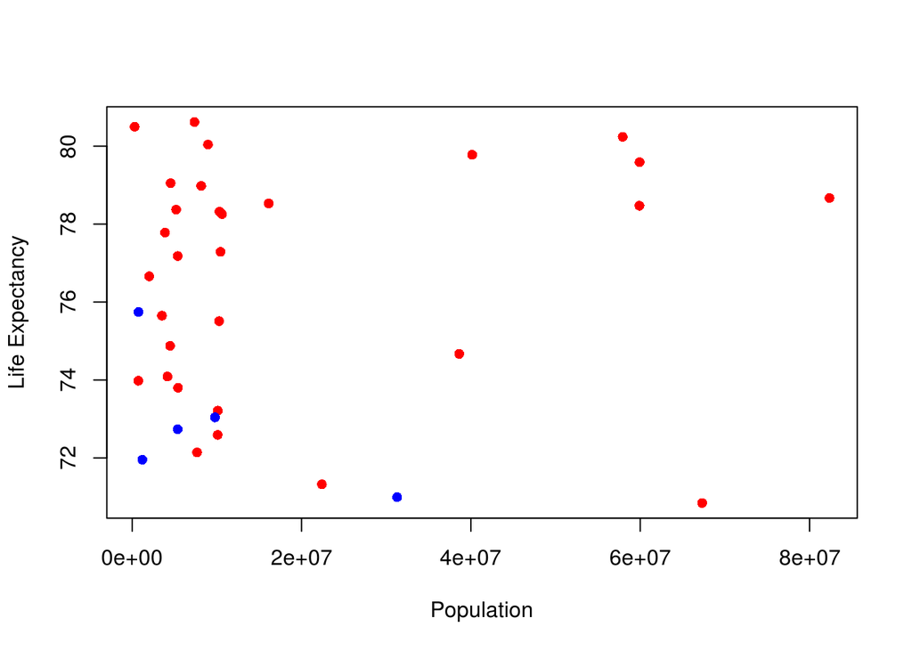

```r
points(afrData$pop, afrData$lifeExp,col="blue",pch=16)
```

Wait, how many African countries did we have?

```r
nrow(afrData)
```

```
## [1] 52
```

The problem here is that the initial limits of the y axis were defined using the life expectancy range of the European data. We can only add points to the existing plotting window, so any African countries with life expectancy outside this range will not get displayed.

We can define the axes when we create the plot using `xlim` and `ylim`.

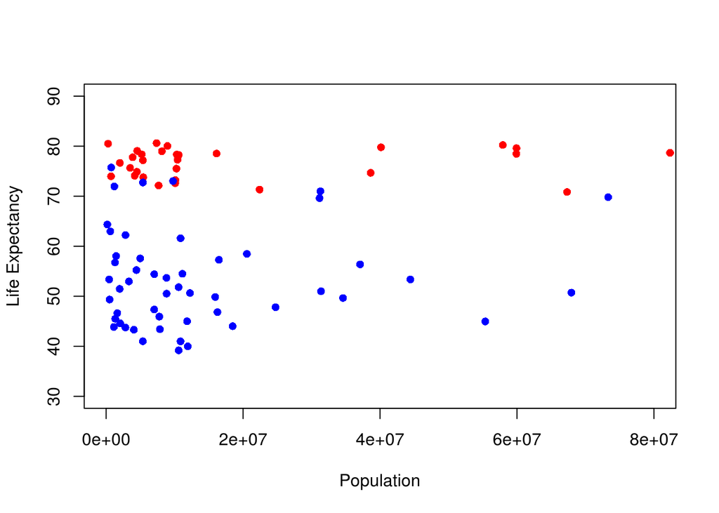

```r
plot(euroData$pop, euroData$lifeExp,col="red",
     pch=16,
     xlab="Population",
     ylab="Life Expectancy",
     xlim=c(0,8e7),ylim=c(30,90))
points(afrData$pop, afrData$lifeExp,col="blue",pch=16)
```

Other useful functions for adding features to an existing plot include `text`, `abline`, `grid`, `legend` among others

Another useful trick for plotting is to take advantage of pre-existing colour palettes in R. The `RColorBrewer` package is a useful package for such palettes; many of which are friendly to those with visual impairments.

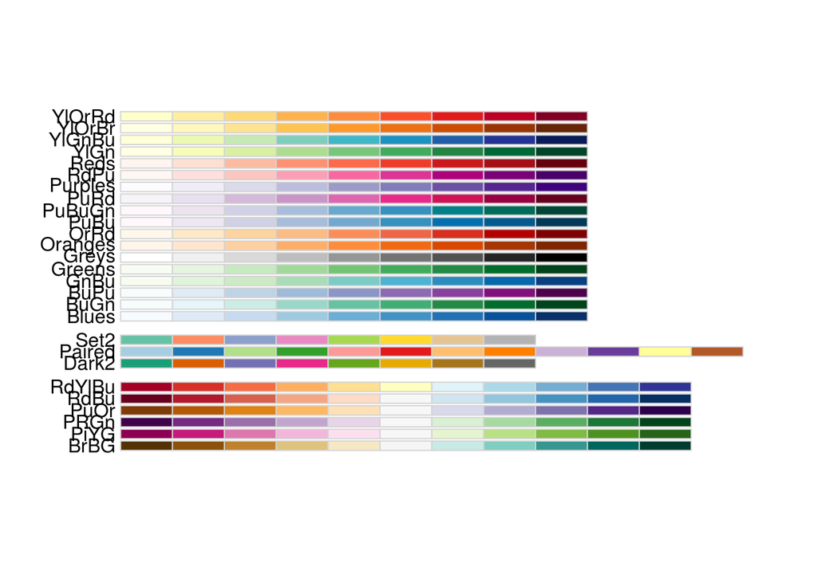

```r
library(RColorBrewer)
display.brewer.all(colorblindFriendly = TRUE)
```

The `brewer.pal` function can return the names of `n` colours from one of the pre-defined palettes to be used as a `col` argument to a plotting function.

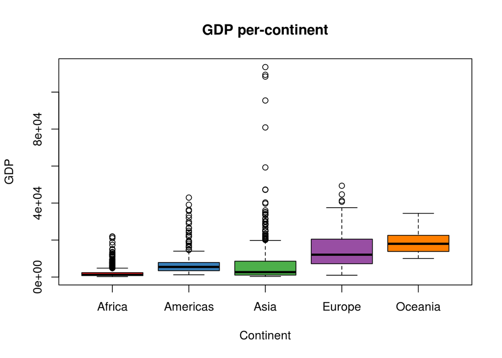

```r
boxplot(gapminder$gdpPercap ~ gapminder$continent,col=brewer.pal(5,"Set1"),
        main="GDP per-continent",
        xlab="Continent",
        ylab="GDP")
```

## Statistical Testing

We can’t really have a run-through of the R language without at least *mentioning* statistics! However, like plotting it is a vast field. The main challenges are putting your data in the correct format (which we have covered here), and deciding which test to use (**which R will not advise you on!**)

- If you have some background in statistics you can see this course from the [Babraham Institute Bioinformatics Core](http://www.bioinformatics.babraham.ac.uk/training/R_Statistics/Introduction%20to%20Statistics%20with%20R.pdf) about how to perform statistical testing in R.
- If you need a more basic grounding in which statistical test to use, you can see this course from [CRUK Cambridge Institute](http://bioinformatics-core-shared-training.github.io/IntroductionToStats/)

The `t.test` function is probably the most fundamental statistical testing function in R, and can be adapted to many different situations. Full details are given in the help page `?t.test`. Lets consider we have two vectors of normally-distributed data that we can visualise using a boxplot.

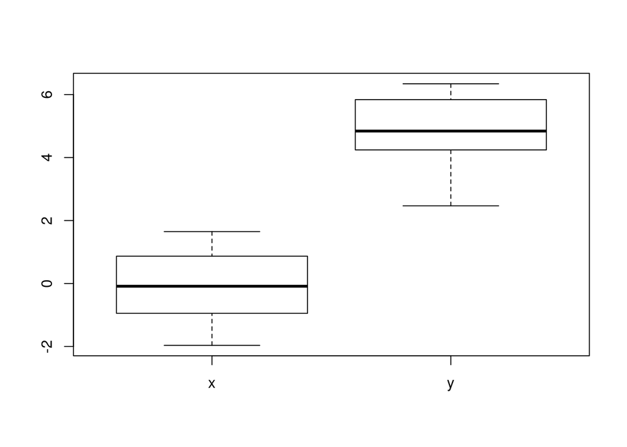

```r
x <- rnorm(20)
y <- rnorm(20, 5,1)
df <- data.frame(x,y)
boxplot(df)
```

The output from `t.test` can be used to judge if there is a statistically-significant difference in means:-

```r
t.test(x,y)
```

```
##
##  Welch Two Sample t-test
##
## data:  x and y
## t = -14.644, df = 37.916, p-value < 2.2e-16
## alternative hypothesis: true difference in means is not equal to 0
## 95 percent confidence interval:
##  -5.648556 -4.276400
## sample estimates:
##  mean of x  mean of y
## -0.1040468  4.8584312
```

If our data were paired we could set the argument `paired=TRUE` to use a different flavour of the test

```r
t.test(x,y,paired = TRUE)
```

```
##
##  Paired t-test
##
## data:  x and y
## t = -14.505, df = 19, p-value = 9.913e-12
## alternative hypothesis: true difference in means is not equal to 0
## 95 percent confidence interval:
##  -5.678529 -4.246427
## sample estimates:
## mean of the differences
##               -4.962478
```

Similarly, if our data have different variances we can adjust the test accordingly:-

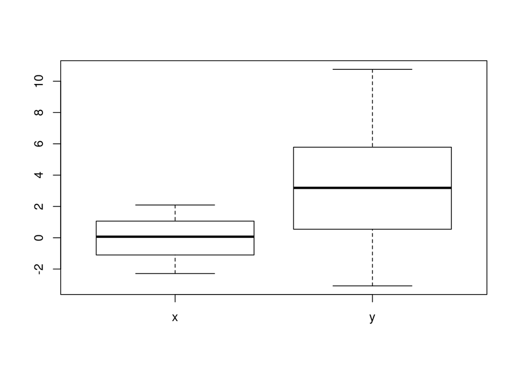

```r
x <- rnorm(20)
y <- rnorm(20, 5,4)
df <- data.frame(x,y)
boxplot(df)
```

```r
t.test(x,y,var.equal = FALSE)
```

```
##
##  Welch Two Sample t-test
##
## data:  x and y
## t = -3.7609, df = 23.609, p-value = 0.0009824
## alternative hypothesis: true difference in means is not equal to 0
## 95 percent confidence interval:
##  -5.067749 -1.474437
## sample estimates:
##  mean of x  mean of y
## 0.04085385 3.31194675
```

Were our data not normally-distributed we could use `wilcox.test`, for example. Fortunately, most statistical tests can be accessed in a similar manner, so it is easy to switch between using different tests provided your data are in the correct format. To re-iterate, the skill is in choosing which test is appropriate.